# MiniProject de classification d'images multi-classes à l'aide de réseaux de neurones convolutifs CNNs

## Samba DIALLO

In this Project, we will tackle a multi-class image classification problem using Convolutional Neural Networks (CNNs). The dataset contains color images that belong to 10 different classes.

It is split into:

- 50000 images for training
- 10000 images for testing

We'll also reserve 10000 images from the training set for validation. So the final split will be:

- 40000 images for training
- 10000 for validation
- 10000 for testing

**1. First CNN architecture implementation**

We will create a CNN architecture and train our model and compare the results (in terms of accuracy and loss) for training and validation dataset. Then, we will identify the overfitting issue in this model. Do not forget to save our model and history (`.keras` and `.pickle`)

**2. Mitigating overfitting**

To reduce overfitting problem, we will implement:

- Dropout
- Norm penalization
- Both Dropout and Norm penalization
- Your proposed model

**3. Discussion**

# 0. Importing packages and preparing data

Necessary libraries for data handling, modeling, and visualization

```python
import numpy as np
import matplotlib.pyplot as plt
import tensorflow as tf
import cv2
import gc
import os
import pickle

from keras.datasets import cifar10
from keras.utils import to_categorical
from keras import models
from keras import layers
from keras import regularizers
from tensorflow.keras.preprocessing import image
```

The dataset CIFAR10 contains 10-classes of objects from `keras.datasets`.

Each image belongs to one of the following 10 categories:

1. Airplane
2. Automobile
3. Bird
4. Cat
5. Deer
6. Dog
7. Frog
8. Horse
9. Ship
10. Truck

We have 5000 images for each class in training dataset, whereas we have 1000 images for each class in test dataset (a balanced dataset).

Now, let's load CIFAR-10 dataset, which is already divided into training and test sets.

```python
(data_train, label_train), (data_test, label_test) = cifar10.load_data()
```

```
Downloading data from https://www.cs.toronto.edu/~kriz/cifar-10-python.tar.gz
170498071/170498071 ━━━━━━━━━━━━━━━━━━━━ 27s 0us/step
```

```python
data_train.shape, data_test.shape
```

```
((50000, 32, 32, 3), (10000, 32, 32, 3))
```

We see the dimension of each image is (32, 32, 3), which means each image has a resolution of 32x32 pixels and 3 color channels (RGB).

Let's check some image examples.

```python
class_names = ['airplane', 'automobile', 'bird', 'cat', 'deer',
               'dog', 'frog', 'horse', 'ship', 'truck']
```

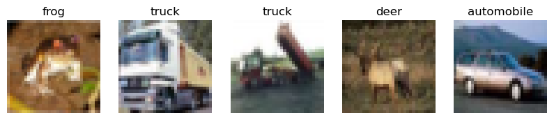

```python
plt.figure(figsize=(10, 5))
for i in range(5):
    img = cv2.resize(data_train[i], (32,32), interpolation=cv2.INTER_CUBIC)
    plt.subplot(1, 5, i + 1)
    plt.imshow(img)
    plt.title(class_names[label_train[i][0]])
    plt.axis('off')

plt.show()
```

Since the images in 32x32 pixels have low resolution, we can improve their quality by increasing the dimensions to 64x64 pixels.

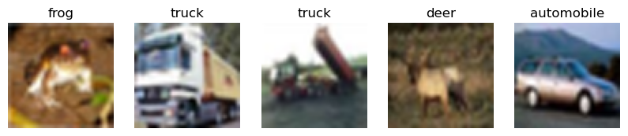

```python
new_size = (64, 64)

plt.figure(figsize=(10, 5))
for i in range(5):
    img = cv2.resize(data_train[i], new_size, interpolation=cv2.INTER_CUBIC)
    plt.subplot(1, 5, i + 1)
    plt.imshow(img)
    plt.title(class_names[label_train[i][0]])
    plt.axis('off')

plt.show()
```

Even though these are still not in perfect resolution, we will resize our images to 64x64 pixels for the rest of this assignment.

We have already training and test dataset coming from `keras.datasets.cifar10`. Now, we will also split our training set into training and validation dataset in order to have finally three sets:

1. Training dataset
2. Validation dataset
3. Test dataset

```python
x_train = np.array([cv2.resize(img, new_size, interpolation=cv2.INTER_CUBIC) for img in data_train[:40000]])
x_val = np.array([cv2.resize(img, new_size, interpolation=cv2.INTER_CUBIC) for img in data_train[40000:]])
x_test = np.array([cv2.resize(img, new_size, interpolation=cv2.INTER_CUBIC) for img in data_test])
```

Since we have classes such as 0, 1, 2, ..., 9 for the labels, we need to categorically encode these labels.

```python
y_train = to_categorical(label_train[:40000], 10)
y_val = to_categorical(label_train[40000:], 10)
y_test = to_categorical(label_test, 10)
```

Let's check the dimensions of our sets.

```python
print(x_train.shape, y_train.shape)
print(x_val.shape, y_val.shape)
print(x_test.shape, y_test.shape)
```

```
(40000, 64, 64, 3) (40000, 10)
(10000, 64, 64, 3) (10000, 10)
(10000, 64, 64, 3) (10000, 10)
```

Pre-processing for images before using them in our model (normalization of the data and preparing generators with batches of pre-processed tensor)

```python
train_datagen  = image.ImageDataGenerator(rescale=1./255)
test_datagen = image.ImageDataGenerator(rescale=1./255)
```

```python
batch_size_gen = 64

train_generator = train_datagen.flow(
        x_train, y_train,
        batch_size=batch_size_gen)

validation_generator = test_datagen.flow(
        x_val, y_val,
        batch_size=batch_size_gen)

test_generator = test_datagen.flow(
        x_test, y_test,
        batch_size=batch_size_gen)
```

# 1. First CNN architecture implementation

```python
model = models.Sequential()
model.add(layers.Conv2D(32, (3,3),activation="relu", padding="same", input_shape=x_train.shape[1:]))
model.add(layers.MaxPooling2D((2,2)))
model.add(layers.Conv2D(64, (3,3) ,activation="relu"))
model.add(layers.MaxPooling2D((2,2)))
model.add(layers.Conv2D(128,(3,3),activation="relu",))
model.add(layers.MaxPooling2D((2,2)))
model.add(layers.Conv2D(256,(3,3),activation="relu",))
model.add(layers.MaxPooling2D((2,2)))
model.add(layers.Flatten())
model.add(layers.Dense(128, activation="relu"))
model.add(layers.Dense(64, activation="relu"))
model.add(layers.Dense(10, activation="softmax"))

model.summary()
model.compile(optimizer='adam', loss='categorical_crossentropy', metrics=['acc'])
```

```
Model: "sequential"
```

```
┏━━━━━━━━━━━━━━━━━━━━━━━━━━━━━━━━━┳━━━━━━━━━━━━━━━━━━━━━━━━┳━━━━━━━━━━━━━━━┓
┃ Layer (type)                    ┃ Output Shape           ┃       Param # ┃
┡━━━━━━━━━━━━━━━━━━━━━━━━━━━━━━━━━╇━━━━━━━━━━━━━━━━━━━━━━━━╇━━━━━━━━━━━━━━━┩
│ conv2d (Conv2D)                 │ (None, 64, 64, 32)     │           896 │
├─────────────────────────────────┼────────────────────────┼───────────────┤
│ max_pooling2d (MaxPooling2D)    │ (None, 32, 32, 32)     │             0 │
├─────────────────────────────────┼────────────────────────┼───────────────┤
│ conv2d_1 (Conv2D)               │ (None, 30, 30, 64)     │        18,496 │
├─────────────────────────────────┼────────────────────────┼───────────────┤
│ max_pooling2d_1 (MaxPooling2D)  │ (None, 15, 15, 64)     │             0 │
├─────────────────────────────────┼────────────────────────┼───────────────┤
│ conv2d_2 (Conv2D)               │ (None, 13, 13, 128)    │        73,856 │
├─────────────────────────────────┼────────────────────────┼───────────────┤
│ max_pooling2d_2 (MaxPooling2D)  │ (None, 6, 6, 128)      │             0 │
├─────────────────────────────────┼────────────────────────┼───────────────┤
│ conv2d_3 (Conv2D)               │ (None, 4, 4, 256)      │       295,168 │
├─────────────────────────────────┼────────────────────────┼───────────────┤
│ max_pooling2d_3 (MaxPooling2D)  │ (None, 2, 2, 256)      │             0 │
├─────────────────────────────────┼────────────────────────┼───────────────┤
│ flatten (Flatten)               │ (None, 1024)           │             0 │
├─────────────────────────────────┼────────────────────────┼───────────────┤
│ dense (Dense)                   │ (None, 128)            │       131,200 │
├─────────────────────────────────┼────────────────────────┼───────────────┤
│ dense_1 (Dense)                 │ (None, 64)             │         8,256 │
├─────────────────────────────────┼────────────────────────┼───────────────┤
│ dense_2 (Dense)                 │ (None, 10)             │           650 │
└─────────────────────────────────┴────────────────────────┴───────────────┘
```

```
 Total params: 528,522 (2.02 MB)
```

```
 Trainable params: 528,522 (2.02 MB)
```

```
 Non-trainable params: 0 (0.00 B)
```

## 1.2 Training

Note that if we do not explicitly give the steps per epoch for training, the model calculates it automatically via the number of data / batch size which is 40000/64 = 625 in our case.

```python
history = model.fit(train_generator,
          epochs=10,
          validation_data=validation_generator
)
```

```
625/625 ━━━━━━━━━━━━━━━━━━━━ 162s 252ms/step - acc: 0.2849 - loss: 1.9086 - val_acc: 0.5235 - val_loss: 1.3215
625/625 ━━━━━━━━━━━━━━━━━━━━ 206s 330ms/step - acc: 0.5555 - loss: 1.2479 - val_acc: 0.6195 - val_loss: 1.0979
625/625 ━━━━━━━━━━━━━━━━━━━━ 172s 275ms/step - acc: 0.6355 - loss: 1.0297 - val_acc: 0.6685 - val_loss: 0.9525
625/625 ━━━━━━━━━━━━━━━━━━━━ 110s 176ms/step - acc: 0.6949 - loss: 0.8651 - val_acc: 0.6928 - val_loss: 0.9049
625/625 ━━━━━━━━━━━━━━━━━━━━ 107s 171ms/step - acc: 0.7375 - loss: 0.7470 - val_acc: 0.7059 - val_loss: 0.8588
625/625 ━━━━━━━━━━━━━━━━━━━━ 106s 170ms/step - acc: 0.7703 - loss: 0.6600 - val_acc: 0.7209 - val_loss: 0.8353
625/625 ━━━━━━━━━━━━━━━━━━━━ 106s 170ms/step - acc: 0.7982 - loss: 0.5714 - val_acc: 0.7348 - val_loss: 0.7877
625/625 ━━━━━━━━━━━━━━━━━━━━ 105s 168ms/step - acc: 0.8246 - loss: 0.4959 - val_acc: 0.7376 - val_loss: 0.7980
625/625 ━━━━━━━━━━━━━━━━━━━━ 105s 168ms/step - acc: 0.8531 - loss: 0.4233 - val_acc: 0.7311 - val_loss: 0.8849
625/625 ━━━━━━━━━━━━━━━━━━━━ 105s 169ms/step - acc: 0.8664 - loss: 0.3771 - val_acc: 0.7503 - val_loss: 0.8291
```

## 1.3 Evaluation

```python
test_loss, test_acc = model.evaluate(test_generator)

print(f"Test accuracy: {test_acc:.4f}")
```

```
157/157 ━━━━━━━━━━━━━━━━━━━━ 11s 63ms/step - acc: 0.1073 - loss: 2.3032
Test accuracy: 0.1102
```

Let's plot the loss and accuracy of the model over the training and validation data during training:

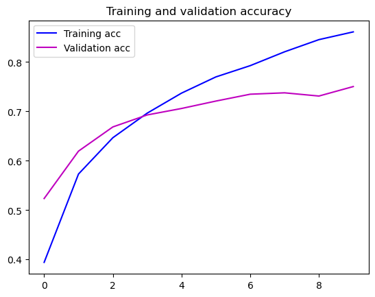

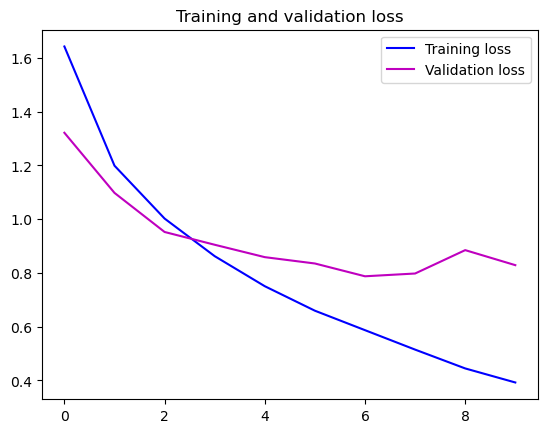

```python
acc = history.history['acc']
val_acc = history.history['val_acc']
loss = history.history['loss']
val_loss = history.history['val_loss']

epochs = range(len(acc))

plt.plot(epochs, acc, 'b', label='Training acc')
plt.plot(epochs, val_acc, 'm', label='Validation acc')
plt.title('Training and validation accuracy')
plt.legend()

plt.figure()

plt.plot(epochs, loss, 'b', label='Training loss')
plt.plot(epochs, val_loss, 'm', label='Validation loss')
plt.title('Training and validation loss')
plt.legend()

plt.show()
```

## 1.4 Save model

```python
model.save("model_original.keras")

with open("history_original.pickle", 'wb') as f:
   pickle.dump(history.history, f)
```

```python
# Clean the memory
tf.keras.backend.clear_session()
del model
gc.collect()
```

```
0
```

```python
class History:
    def __init__(self, name):
        with open(name, 'rb') as file:
            h = pickle.load(file)
            self.history = h

model = models.load_model("model_original.keras")
history = History("history_original.pickle")
```

# Mitigating Overfitting

When a model learns too well on the training data but performs poorly on new data, it's overfitting. Regularization methods like Dropout and norm penalization help avoid this by making the model more general.

Even if the difference is not huge between training and validation data results, there is still a bit of overfitting in our model. Let’s now try to fix that problem using some regularization methods.

**2.1 Dropout**

**2.2 Norm penalization**

**2.3 Dropout & Norm penalization**

**2.4 Your proposed model**

## 2.1 Dropout

```python
model = models.Sequential()
model.add(layers.Conv2D(32, (3,3),activation="relu", padding="same", input_shape=x_train.shape[1:]))
model.add(layers.MaxPooling2D((2,2)))
model.add(layers.Conv2D(64, (3,3) ,activation="relu"))
model.add(layers.Dropout(0.2))
model.add(layers.MaxPooling2D((2,2)))
model.add(layers.Conv2D(128,(3,3),activation="relu",))
model.add(layers.MaxPooling2D((2,2)))
model.add(layers.Conv2D(256,(3,3),activation="relu",))
model.add(layers.MaxPooling2D((2,2)))
model.add(layers.Flatten())
model.add(layers.Dense(128, activation="relu"))
model.add(layers.Dropout(0.5))
model.add(layers.Dense(64, activation="relu"))
model.add(layers.Dense(10, activation="softmax"))

model.summary()

model.compile(optimizer='adam', loss='categorical_crossentropy', metrics=['acc'])
```

```
Model: "sequential_2"
```

```
┏━━━━━━━━━━━━━━━━━━━━━━━━━━━━━━━━━┳━━━━━━━━━━━━━━━━━━━━━━━━┳━━━━━━━━━━━━━━━┓
┃ Layer (type)                    ┃ Output Shape           ┃       Param # ┃
┡━━━━━━━━━━━━━━━━━━━━━━━━━━━━━━━━━╇━━━━━━━━━━━━━━━━━━━━━━━━╇━━━━━━━━━━━━━━━┩
│ conv2d_8 (Conv2D)               │ (None, 64, 64, 32)     │           896 │
├─────────────────────────────────┼────────────────────────┼───────────────┤
│ max_pooling2d_8 (MaxPooling2D)  │ (None, 32, 32, 32)     │             0 │
├─────────────────────────────────┼────────────────────────┼───────────────┤
│ conv2d_9 (Conv2D)               │ (None, 30, 30, 64)     │        18,496 │
├─────────────────────────────────┼────────────────────────┼───────────────┤
│ dropout (Dropout)               │ (None, 30, 30, 64)     │             0 │
├─────────────────────────────────┼────────────────────────┼───────────────┤
│ max_pooling2d_9 (MaxPooling2D)  │ (None, 15, 15, 64)     │             0 │
├─────────────────────────────────┼────────────────────────┼───────────────┤
│ conv2d_10 (Conv2D)              │ (None, 13, 13, 128)    │        73,856 │
├─────────────────────────────────┼────────────────────────┼───────────────┤
│ max_pooling2d_10 (MaxPooling2D) │ (None, 6, 6, 128)      │             0 │
├─────────────────────────────────┼────────────────────────┼───────────────┤
│ conv2d_11 (Conv2D)              │ (None, 4, 4, 256)      │       295,168 │
├─────────────────────────────────┼────────────────────────┼───────────────┤
│ max_pooling2d_11 (MaxPooling2D) │ (None, 2, 2, 256)      │             0 │
├─────────────────────────────────┼────────────────────────┼───────────────┤
│ flatten_2 (Flatten)             │ (None, 1024)           │             0 │
├─────────────────────────────────┼────────────────────────┼───────────────┤
│ dense_6 (Dense)                 │ (None, 128)            │       131,200 │
├─────────────────────────────────┼────────────────────────┼───────────────┤
│ dropout_1 (Dropout)             │ (None, 128)            │             0 │
├─────────────────────────────────┼────────────────────────┼───────────────┤
│ dense_7 (Dense)                 │ (None, 64)             │         8,256 │
├─────────────────────────────────┼────────────────────────┼───────────────┤
│ dense_8 (Dense)                 │ (None, 10)             │           650 │
└─────────────────────────────────┴────────────────────────┴───────────────┘
```

```
 Total params: 528,522 (2.02 MB)
```

```
 Trainable params: 528,522 (2.02 MB)
```

```
 Non-trainable params: 0 (0.00 B)
```

```python
# Train model
history = model.fit(train_generator,
          epochs=10,
          validation_data=validation_generator
                   )
```

```
625/625 ━━━━━━━━━━━━━━━━━━━━ 163s 255ms/step - acc: 0.2438 - loss: 1.9951 - val_acc: 0.4789 - val_loss: 1.4558
625/625 ━━━━━━━━━━━━━━━━━━━━ 144s 231ms/step - acc: 0.4865 - loss: 1.4164 - val_acc: 0.5988 - val_loss: 1.1539
625/625 ━━━━━━━━━━━━━━━━━━━━ 128s 205ms/step - acc: 0.5753 - loss: 1.1879 - val_acc: 0.6102 - val_loss: 1.1191
625/625 ━━━━━━━━━━━━━━━━━━━━ 131s 210ms/step - acc: 0.6386 - loss: 1.0217 - val_acc: 0.6719 - val_loss: 0.9393
625/625 ━━━━━━━━━━━━━━━━━━━━ 139s 223ms/step - acc: 0.6759 - loss: 0.9237 - val_acc: 0.6968 - val_loss: 0.8688
625/625 ━━━━━━━━━━━━━━━━━━━━ 131s 209ms/step - acc: 0.7178 - loss: 0.8048 - val_acc: 0.6763 - val_loss: 0.9294
625/625 ━━━━━━━━━━━━━━━━━━━━ 127s 204ms/step - acc: 0.7417 - loss: 0.7476 - val_acc: 0.7190 - val_loss: 0.8019
625/625 ━━━━━━━━━━━━━━━━━━━━ 129s 207ms/step - acc: 0.7717 - loss: 0.6565 - val_acc: 0.7344 - val_loss: 0.7687
625/625 ━━━━━━━━━━━━━━━━━━━━ 131s 210ms/step - acc: 0.7921 - loss: 0.6032 - val_acc: 0.7353 - val_loss: 0.7730
625/625 ━━━━━━━━━━━━━━━━━━━━ 133s 214ms/step - acc: 0.8033 - loss: 0.5672 - val_acc: 0.7330 - val_loss: 0.7852
```

```python
# Evaluate model
test_loss, test_acc = model.evaluate(test_generator)
print(f"Test accuracy: {test_acc:.4f}")
```

```
157/157 ━━━━━━━━━━━━━━━━━━━━ 10s 65ms/step - acc: 0.7258 - loss: 0.8184
Test accuracy: 0.7296
```

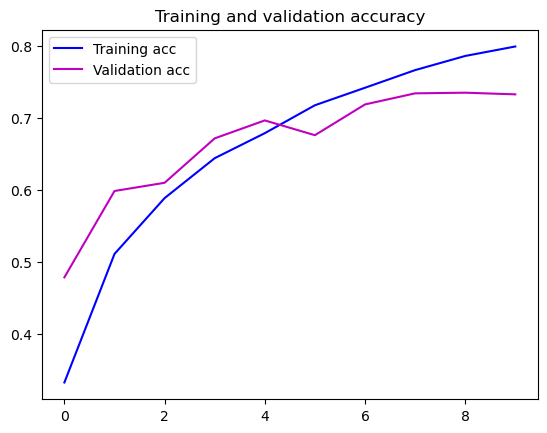

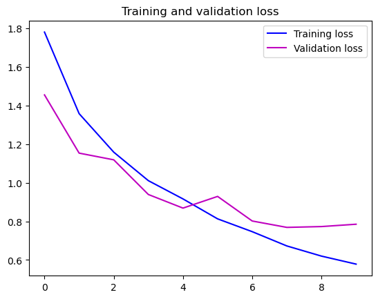

```python
acc = history.history['acc']
val_acc = history.history['val_acc']
loss = history.history['loss']
val_loss = history.history['val_loss']

epochs = range(len(acc))

plt.plot(epochs, acc, 'b', label='Training acc')
plt.plot(epochs, val_acc, 'm', label='Validation acc')
plt.title('Training and validation accuracy')
plt.legend()

plt.figure()

plt.plot(epochs, loss, 'b', label='Training loss')
plt.plot(epochs, val_loss, 'm', label='Validation loss')
plt.title('Training and validation loss')
plt.legend()

plt.show()
```

```python
# Save model
model.save("model_dropout.keras")

with open("history_dropout.pickle", 'wb') as f:
   pickle.dump(history.history, f)
```

```python
# Clean the memory
tf.keras.backend.clear_session()
del model
gc.collect()
```

```
0
```

## 2.2 Norm penalization

Keeping the same model construction, add

- `kernal_regularizer` argument to the first dense layer with an L2 of `0.01

```python
model = models.Sequential()
model.add(layers.Conv2D(32, (3,3),activation="relu", padding="same", input_shape=x_train.shape[1:]))
model.add(layers.MaxPooling2D((2,2)))
model.add(layers.Conv2D(64, (3,3) ,activation="relu"))
model.add(layers.MaxPooling2D((2,2)))
model.add(layers.Conv2D(128,(3,3),activation="relu",))
model.add(layers.MaxPooling2D((2,2)))
model.add(layers.Conv2D(256,(3,3),activation="relu",))
model.add(layers.MaxPooling2D((2,2)))
model.add(layers.Flatten())
model.add(layers.Dense(128, kernel_regularizer=regularizers.l2(0.01),  activation="relu"))
model.add(layers.Dense(64, activation="relu"))
model.add(layers.Dense(10, activation="softmax"))

# Model summary to check the architecture
model.summary()

# Compilation the model with the proper loss function for multi-class clasification
model.compile(optimizer='adam', loss='categorical_crossentropy', metrics=['acc'])
```

```
Model: "sequential_1"
```

```
┏━━━━━━━━━━━━━━━━━━━━━━━━━━━━━━━━━┳━━━━━━━━━━━━━━━━━━━━━━━━┳━━━━━━━━━━━━━━━┓
┃ Layer (type)                    ┃ Output Shape           ┃       Param # ┃
┡━━━━━━━━━━━━━━━━━━━━━━━━━━━━━━━━━╇━━━━━━━━━━━━━━━━━━━━━━━━╇━━━━━━━━━━━━━━━┩
│ conv2d_4 (Conv2D)               │ (None, 64, 64, 32)     │           896 │
├─────────────────────────────────┼────────────────────────┼───────────────┤
│ max_pooling2d_4 (MaxPooling2D)  │ (None, 32, 32, 32)     │             0 │
├─────────────────────────────────┼────────────────────────┼───────────────┤
│ conv2d_5 (Conv2D)               │ (None, 30, 30, 64)     │        18,496 │
├─────────────────────────────────┼────────────────────────┼───────────────┤
│ max_pooling2d_5 (MaxPooling2D)  │ (None, 15, 15, 64)     │             0 │
├─────────────────────────────────┼────────────────────────┼───────────────┤
│ conv2d_6 (Conv2D)               │ (None, 13, 13, 128)    │        73,856 │
├─────────────────────────────────┼────────────────────────┼───────────────┤
│ max_pooling2d_6 (MaxPooling2D)  │ (None, 6, 6, 128)      │             0 │
├─────────────────────────────────┼────────────────────────┼───────────────┤
│ conv2d_7 (Conv2D)               │ (None, 4, 4, 256)      │       295,168 │
├─────────────────────────────────┼────────────────────────┼───────────────┤
│ max_pooling2d_7 (MaxPooling2D)  │ (None, 2, 2, 256)      │             0 │
├─────────────────────────────────┼────────────────────────┼───────────────┤
│ flatten_1 (Flatten)             │ (None, 1024)           │             0 │
├─────────────────────────────────┼────────────────────────┼───────────────┤
│ dense_3 (Dense)                 │ (None, 128)            │       131,200 │
├─────────────────────────────────┼────────────────────────┼───────────────┤
│ dense_4 (Dense)                 │ (None, 64)             │         8,256 │
├─────────────────────────────────┼────────────────────────┼───────────────┤
│ dense_5 (Dense)                 │ (None, 10)             │           650 │
└─────────────────────────────────┴────────────────────────┴───────────────┘
```

```
 Total params: 528,522 (2.02 MB)
```

```
 Trainable params: 528,522 (2.02 MB)
```

```
 Non-trainable params: 0 (0.00 B)
```

```python
# Train model
history = model.fit(train_generator,
          epochs=10,
          validation_data=validation_generator
                   )
```

```
625/625 ━━━━━━━━━━━━━━━━━━━━ 127s 196ms/step - acc: 0.2892 - loss: 2.2625 - val_acc: 0.4596 - val_loss: 1.5204
625/625 ━━━━━━━━━━━━━━━━━━━━ 120s 193ms/step - acc: 0.5236 - loss: 1.3752 - val_acc: 0.6033 - val_loss: 1.1785
625/625 ━━━━━━━━━━━━━━━━━━━━ 121s 193ms/step - acc: 0.6144 - loss: 1.1543 - val_acc: 0.6490 - val_loss: 1.0790
625/625 ━━━━━━━━━━━━━━━━━━━━ 118s 189ms/step - acc: 0.6712 - loss: 1.0052 - val_acc: 0.6868 - val_loss: 0.9859
625/625 ━━━━━━━━━━━━━━━━━━━━ 116s 185ms/step - acc: 0.7178 - loss: 0.8873 - val_acc: 0.6992 - val_loss: 0.9398
625/625 ━━━━━━━━━━━━━━━━━━━━ 129s 206ms/step - acc: 0.7493 - loss: 0.8060 - val_acc: 0.7376 - val_loss: 0.8631
625/625 ━━━━━━━━━━━━━━━━━━━━ 119s 191ms/step - acc: 0.7741 - loss: 0.7280 - val_acc: 0.7366 - val_loss: 0.8648
625/625 ━━━━━━━━━━━━━━━━━━━━ 122s 195ms/step - acc: 0.8005 - loss: 0.6657 - val_acc: 0.7347 - val_loss: 0.8749
625/625 ━━━━━━━━━━━━━━━━━━━━ 118s 189ms/step - acc: 0.8167 - loss: 0.6104 - val_acc: 0.7489 - val_loss: 0.8603
625/625 ━━━━━━━━━━━━━━━━━━━━ 123s 197ms/step - acc: 0.8379 - loss: 0.5510 - val_acc: 0.7497 - val_loss: 0.8628
```

```python
# Evaluate model
test_loss, test_acc = model.evaluate(test_generator)
print(f"Test accuracy: {test_acc:.4f}")
```

```
157/157 ━━━━━━━━━━━━━━━━━━━━ 47s 274ms/step - acc: 0.1003 - loss: 2.3023
Test accuracy: 0.1000
```

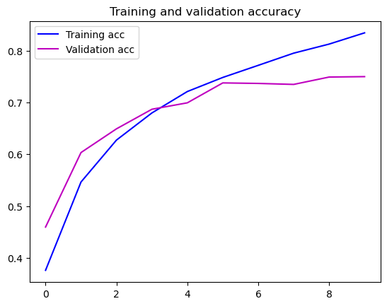

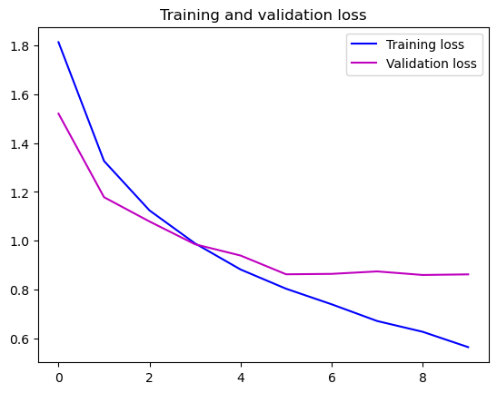

```python
acc = history.history['acc']
val_acc = history.history['val_acc']
loss = history.history['loss']
val_loss = history.history['val_loss']

epochs = range(len(acc))

plt.plot(epochs, acc, 'b', label='Training acc')
plt.plot(epochs, val_acc, 'm', label='Validation acc')
plt.title('Training and validation accuracy')
plt.legend()

plt.figure()

plt.plot(epochs, loss, 'b', label='Training loss')
plt.plot(epochs, val_loss, 'm', label='Validation loss')
plt.title('Training and validation loss')
plt.legend()

plt.show()
```

```python
# Save model
model.save("model_norm.keras")

with open("history_norm.pickle", 'wb') as f:
   pickle.dump(history.history, f)
```

```python
# Clean the memory
tf.keras.backend.clear_session()
del model
gc.collect()
```

```
0
```

## 2.3 Dropout & Norm penalization

```python
model = models.Sequential()
model.add(layers.Conv2D(32, (3,3),activation="relu", padding="same", input_shape=x_train.shape[1:]))
model.add(layers.MaxPooling2D((2,2)))
model.add(layers.Conv2D(64, (3,3) ,activation="relu"))

model.add(layers.MaxPooling2D((2,2)))
model.add(layers.Conv2D(128,(3,3),activation="relu",))
model.add(layers.Dropout(0.2))

model.add(layers.MaxPooling2D((2,2)))
model.add(layers.Conv2D(256,(3,3),activation="relu",))
model.add(layers.MaxPooling2D((2,2)))
model.add(layers.Flatten())
model.add(layers.Dense(128, activation="relu", kernel_regularizer=regularizers.l2(0.01)))
model.add(layers.Dropout(0.5))
model.add(layers.Dense(64, activation="relu"))
model.add(layers.Dense(10, activation="softmax"))

model.summary()

# Compilation the model with the proper loss function for multi-class clasification
model.compile(optimizer='adam', loss='categorical_crossentropy', metrics=['acc'])
```

```
Model: "sequential_1"
```

```
┏━━━━━━━━━━━━━━━━━━━━━━━━━━━━━━━━━┳━━━━━━━━━━━━━━━━━━━━━━━━┳━━━━━━━━━━━━━━━┓
┃ Layer (type)                    ┃ Output Shape           ┃       Param # ┃
┡━━━━━━━━━━━━━━━━━━━━━━━━━━━━━━━━━╇━━━━━━━━━━━━━━━━━━━━━━━━╇━━━━━━━━━━━━━━━┩
│ conv2d_4 (Conv2D)               │ (None, 64, 64, 32)     │           896 │
├─────────────────────────────────┼────────────────────────┼───────────────┤
│ max_pooling2d_4 (MaxPooling2D)  │ (None, 32, 32, 32)     │             0 │
├─────────────────────────────────┼────────────────────────┼───────────────┤
│ conv2d_5 (Conv2D)               │ (None, 30, 30, 64)     │        18,496 │
├─────────────────────────────────┼────────────────────────┼───────────────┤
│ max_pooling2d_5 (MaxPooling2D)  │ (None, 15, 15, 64)     │             0 │
├─────────────────────────────────┼────────────────────────┼───────────────┤
│ conv2d_6 (Conv2D)               │ (None, 13, 13, 128)    │        73,856 │
├─────────────────────────────────┼────────────────────────┼───────────────┤
│ dropout_2 (Dropout)             │ (None, 13, 13, 128)    │             0 │
├─────────────────────────────────┼────────────────────────┼───────────────┤
│ max_pooling2d_6 (MaxPooling2D)  │ (None, 6, 6, 128)      │             0 │
├─────────────────────────────────┼────────────────────────┼───────────────┤
│ conv2d_7 (Conv2D)               │ (None, 4, 4, 256)      │       295,168 │
├─────────────────────────────────┼────────────────────────┼───────────────┤
│ max_pooling2d_7 (MaxPooling2D)  │ (None, 2, 2, 256)      │             0 │
├─────────────────────────────────┼────────────────────────┼───────────────┤
│ flatten_1 (Flatten)             │ (None, 1024)           │             0 │
├─────────────────────────────────┼────────────────────────┼───────────────┤
│ dense_3 (Dense)                 │ (None, 128)            │       131,200 │
├─────────────────────────────────┼────────────────────────┼───────────────┤
│ dropout_3 (Dropout)             │ (None, 128)            │             0 │
├─────────────────────────────────┼────────────────────────┼───────────────┤
│ dense_4 (Dense)                 │ (None, 64)             │         8,256 │
├─────────────────────────────────┼────────────────────────┼───────────────┤
│ dense_5 (Dense)                 │ (None, 10)             │           650 │
└─────────────────────────────────┴────────────────────────┴───────────────┘
```

```
 Total params: 528,522 (2.02 MB)
```

```
 Trainable params: 528,522 (2.02 MB)
```

```
 Non-trainable params: 0 (0.00 B)
```

```python
# Train model
history = model.fit(train_generator,
          epochs=10,
          validation_data=validation_generator
                   )
```

```
625/625 ━━━━━━━━━━━━━━━━━━━━ 139s 216ms/step - acc: 0.2414 - loss: 2.3637 - val_acc: 0.4723 - val_loss: 1.5285
625/625 ━━━━━━━━━━━━━━━━━━━━ 130s 208ms/step - acc: 0.4736 - loss: 1.5156 - val_acc: 0.5655 - val_loss: 1.3149
625/625 ━━━━━━━━━━━━━━━━━━━━ 127s 203ms/step - acc: 0.5510 - loss: 1.3315 - val_acc: 0.6100 - val_loss: 1.1993
625/625 ━━━━━━━━━━━━━━━━━━━━ 126s 202ms/step - acc: 0.5982 - loss: 1.2192 - val_acc: 0.6498 - val_loss: 1.0797
625/625 ━━━━━━━━━━━━━━━━━━━━ 135s 216ms/step - acc: 0.6363 - loss: 1.1253 - val_acc: 0.6793 - val_loss: 1.0169
625/625 ━━━━━━━━━━━━━━━━━━━━ 123s 197ms/step - acc: 0.6735 - loss: 1.0308 - val_acc: 0.6903 - val_loss: 0.9970
625/625 ━━━━━━━━━━━━━━━━━━━━ 125s 200ms/step - acc: 0.6976 - loss: 0.9714 - val_acc: 0.6928 - val_loss: 0.9849
625/625 ━━━━━━━━━━━━━━━━━━━━ 125s 200ms/step - acc: 0.7231 - loss: 0.9054 - val_acc: 0.7244 - val_loss: 0.9030
625/625 ━━━━━━━━━━━━━━━━━━━━ 121s 194ms/step - acc: 0.7415 - loss: 0.8539 - val_acc: 0.7380 - val_loss: 0.8767
625/625 ━━━━━━━━━━━━━━━━━━━━ 120s 192ms/step - acc: 0.7540 - loss: 0.8181 - val_acc: 0.7432 - val_loss: 0.8588
```

```python
# Evaluate model
test_loss, test_acc = model.evaluate(test_generator)
print(f"Test accuracy: {test_acc:.4f}")
```

```
157/157 ━━━━━━━━━━━━━━━━━━━━ 1s 6ms/step - acc: 0.7167 - loss: 0.9092
Test accuracy: 0.7153
```

[figure not shown]

[figure not shown]

```python
acc = history.history['acc']
val_acc = history.history['val_acc']
loss = history.history['loss']
val_loss = history.history['val_loss']

epochs = range(len(acc))

plt.plot(epochs, acc, 'b', label='Training acc')
plt.plot(epochs, val_acc, 'm', label='Validation acc')
plt.title('Training and validation accuracy')
plt.legend()

plt.figure()

plt.plot(epochs, loss, 'b', label='Training loss')
plt.plot(epochs, val_loss, 'm', label='Validation loss')
plt.title('Training and validation loss')
plt.legend()

plt.show()
```

```python
# Save model
model.save("model_dropout_norm.keras")

with open("history_dropout_norm.pickle", 'wb') as f:
   pickle.dump(history.history, f)
```

```python
# Clean the memory
tf.keras.backend.clear_session()
del model
gc.collect()
```

```
0
```

## 2.4 Our proposed model

Now, we will propose our own model.

```python
model = models.Sequential()
model.add(layers.Conv2D(22, (3,3),activation="relu", padding="same", input_shape=x_train.shape[1:]))
model.add(layers.MaxPooling2D((2,2)))
model.add(layers.Conv2D(64, (3,3) ,activation="relu"))
model.add(layers.MaxPooling2D((2,2)))
model.add(layers.Conv2D(128,(3,3),activation="relu",))
model.add(layers.MaxPooling2D((2,2)))
model.add(layers.Conv2D(256,(3,3),activation="relu",))
model.add(layers.MaxPooling2D((2,2)))
model.add(layers.Flatten())
model.add(layers.Dense(128, kernel_regularizer=regularizers.l2(0.03),  activation="relu"))
model.add(layers.Dense(64, activation="tanh"))
model.add(layers.Dense(10, activation="softmax"))

model.summary()

# Compilation the model with the proper loss function for multi-class clasification
model.compile(optimizer='adam', loss='categorical_crossentropy', metrics=['acc'])
```

```
Model: "sequential"
```

```
┏━━━━━━━━━━━━━━━━━━━━━━━━━━━━━━━━━┳━━━━━━━━━━━━━━━━━━━━━━━━┳━━━━━━━━━━━━━━━┓
┃ Layer (type)                    ┃ Output Shape           ┃       Param # ┃
┡━━━━━━━━━━━━━━━━━━━━━━━━━━━━━━━━━╇━━━━━━━━━━━━━━━━━━━━━━━━╇━━━━━━━━━━━━━━━┩
│ conv2d (Conv2D)                 │ (None, 64, 64, 22)     │           616 │
├─────────────────────────────────┼────────────────────────┼───────────────┤
│ max_pooling2d (MaxPooling2D)    │ (None, 32, 32, 22)     │             0 │
├─────────────────────────────────┼────────────────────────┼───────────────┤
│ conv2d_1 (Conv2D)               │ (None, 30, 30, 64)     │        12,736 │
├─────────────────────────────────┼────────────────────────┼───────────────┤
│ max_pooling2d_1 (MaxPooling2D)  │ (None, 15, 15, 64)     │             0 │
├─────────────────────────────────┼────────────────────────┼───────────────┤
│ conv2d_2 (Conv2D)               │ (None, 13, 13, 128)    │        73,856 │
├─────────────────────────────────┼────────────────────────┼───────────────┤
│ max_pooling2d_2 (MaxPooling2D)  │ (None, 6, 6, 128)      │             0 │
├─────────────────────────────────┼────────────────────────┼───────────────┤
│ conv2d_3 (Conv2D)               │ (None, 4, 4, 256)      │       295,168 │
├─────────────────────────────────┼────────────────────────┼───────────────┤
│ max_pooling2d_3 (MaxPooling2D)  │ (None, 2, 2, 256)      │             0 │
├─────────────────────────────────┼────────────────────────┼───────────────┤
│ flatten (Flatten)               │ (None, 1024)           │             0 │
├─────────────────────────────────┼────────────────────────┼───────────────┤
│ dense (Dense)                   │ (None, 128)            │       131,200 │
├─────────────────────────────────┼────────────────────────┼───────────────┤
│ dense_1 (Dense)                 │ (None, 64)             │         8,256 │
├─────────────────────────────────┼────────────────────────┼───────────────┤
│ dense_2 (Dense)                 │ (None, 10)             │           650 │
└─────────────────────────────────┴────────────────────────┴───────────────┘
```

```
 Total params: 522,482 (1.99 MB)
```

```
 Trainable params: 522,482 (1.99 MB)
```

```
 Non-trainable params: 0 (0.00 B)
```

```python
# Train model
history = model.fit(train_generator,
          epochs=10,
          validation_data=validation_generator
                   )
```

```
625/625 ━━━━━━━━━━━━━━━━━━━━ 14s 14ms/step - acc: 0.2759 - loss: 2.8836 - val_acc: 0.4544 - val_loss: 1.5276
625/625 ━━━━━━━━━━━━━━━━━━━━ 8s 12ms/step - acc: 0.5026 - loss: 1.4230 - val_acc: 0.5693 - val_loss: 1.2889
625/625 ━━━━━━━━━━━━━━━━━━━━ 7s 11ms/step - acc: 0.5874 - loss: 1.2356 - val_acc: 0.6272 - val_loss: 1.1369
625/625 ━━━━━━━━━━━━━━━━━━━━ 8s 13ms/step - acc: 0.6427 - loss: 1.0955 - val_acc: 0.6534 - val_loss: 1.0617
625/625 ━━━━━━━━━━━━━━━━━━━━ 7s 11ms/step - acc: 0.6813 - loss: 0.9901 - val_acc: 0.6860 - val_loss: 0.9944
625/625 ━━━━━━━━━━━━━━━━━━━━ 8s 12ms/step - acc: 0.7157 - loss: 0.8995 - val_acc: 0.6850 - val_loss: 0.9869
625/625 ━━━━━━━━━━━━━━━━━━━━ 7s 12ms/step - acc: 0.7370 - loss: 0.8407 - val_acc: 0.7008 - val_loss: 0.9526
625/625 ━━━━━━━━━━━━━━━━━━━━ 8s 12ms/step - acc: 0.7649 - loss: 0.7709 - val_acc: 0.7109 - val_loss: 0.9208
625/625 ━━━━━━━━━━━━━━━━━━━━ 11s 14ms/step - acc: 0.7838 - loss: 0.7114 - val_acc: 0.7210 - val_loss: 0.9162
625/625 ━━━━━━━━━━━━━━━━━━━━ 7s 12ms/step - acc: 0.7934 - loss: 0.6796 - val_acc: 0.7378 - val_loss: 0.8639
```

```python
# Evaluate model
test_loss, test_acc = model.evaluate(test_generator)
print(f"Test accuracy: {test_acc:.4f}")
```

```
157/157 ━━━━━━━━━━━━━━━━━━━━ 9s 50ms/step - acc: 0.1068 - loss: 9.0880
Test accuracy: 0.1027
```

[figure not shown]

[figure not shown]

```python
acc = history.history['acc']
val_acc = history.history['val_acc']
loss = history.history['loss']
val_loss = history.history['val_loss']

epochs = range(len(acc))

plt.plot(epochs, acc, 'b', label='Training acc')
plt.plot(epochs, val_acc, 'm', label='Validation acc')
plt.title('Training and validation accuracy')
plt.legend()

plt.figure()

plt.plot(epochs, loss, 'b', label='Training loss')
plt.plot(epochs, val_loss, 'm', label='Validation loss')
plt.title('Training and validation loss')
plt.legend()

plt.show()
```

```python
# Save model
model.save("model_proposed.keras")

with open("history_proposed.pickle", 'wb') as f:
   pickle.dump(history.history, f)
```

```python
# Clean the memory
tf.keras.backend.clear_session()
del model
gc.collect()
```

```
8832
```

## 2.5 Prediction on an image

Now, we can use any trained model that you saved to predict the label of an image.

For this task, we can download an image among the list ('airplane', 'automobile', 'bird', 'cat', 'deer', 'dog', 'frog', 'horse', 'ship', 'truck') or we can take a picture of it by ourselves.

We do not need to modify any code here. We will just:

- change the model name while loading it
- put a new image in our directory where this python file places in and replace the code with its name

```python
def detect_object(img_path, model):

    img = image.load_img(img_path)
    img_resized = img.resize((64, 64))

    img_array = image.img_to_array(img_resized) / 255.0
    img_array = img_array.reshape(1, 64, 64, 3)

    class_names = ['airplane', 'automobile', 'bird', 'cat', 'deer',
                   'dog', 'frog', 'horse', 'ship', 'truck']

    pred = model.predict(img_array)
    predicted_class = np.argmax(pred)

    label_image = class_names[predicted_class]

    # plt.imshow(img)
    plt.imshow(img_resized)
    plt.title(f"Predicted: {label_image} with a probability of {100 * np.max(pred):.2f}%")
    plt.axis('off')
    plt.show()
```

```python
model = models.load_model("model_original.keras")
```

```
1/1 ━━━━━━━━━━━━━━━━━━━━ 0s 87ms/step
```

[figure not shown]

```python
detect_object("avi.png", model)
```

# 3. Discussion

Present here our remarks on the results in two-three paragraphs. For example:

1. How much do the loss and accuracy for the training and validation sets change after adding Dropout and norm penalization?
2. Discuss the test accuracy achieved by the models for a 10-class classification task. Note that without using any AI model and selecting a class at random among n classes, the probability of choosing the correct class would be 1/*n*, which is 1/10 = 0.10 in our case, compared to 0.50 in binary classification.
3. Explain the modifications in your proposed model and discuss its advantages and limitations.

# 1. After adding Dropout and norm regularization (often L2), we typically observe:

A slight increase in training loss and a decrease in training accuracy. This is normal: Dropout randomly deactivates neurons during training, preventing the model from overfitting to the training data.

# 2. In a 10-class classification task, the baseline accuracy is 1/10 = 0.10 (or 10%).

With a well-trained model, an accuracy of 85% to 95% is often achieved on the test set, depending on: the model architecture (CNNs often provide better results).

# 3. Modifications made to the model:

Integrated L2 regularization to penalize excessively large weights.

Advantages:

Less variance between training runs.

Limitations:

More complex tuning: It requires adjusting the Dropout rate, L2 regularization value, etc.

Dropout may slow down convergence, requiring more iterations (epochs).